# Métodos Clássicos para Previsão de Séries Temporais

#### Filtro de Kalman

O filtro de Kalman é um algoritmo que utiliza medicões de grandezas ao longo do tempo que possuem ruído e outras incertezas de medida. Ele busca gerar resultados que tendam a se aproximar dos valores reais das séries temporais. Abaixo pode-se visualizar o procedimento de estimação para a série LTN.

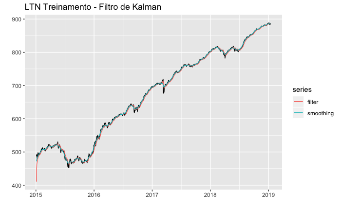

```r
set.seed(1)
n <- length(LTN)
LTN_matriz <- matrix(LTN, nrow=n, ncol=1)
m1 <- SS(y = LTN_matriz,
         Fmat = function(tt, x, phi) return(matrix(1)),
         Gmat = function(tt,x,phi) return(matrix(1)),
         Wmat = function(tt,x,phi) return(matrix(0.1)),
         Vmat = function(tt,x,phi) return(matrix(2)),
         m0 = matrix(25), C0 = matrix(10))

m1.f <- kfilter(m1)
m1.s <- smoother(m1.f)
m1.f_ts <- ts(m1.f$m, start = c(2015,3), end=c(2019,9), frequency = 250)
m1.s_ts <- ts(m1.s$m, start = c(2015,3), end=c(2019,9), frequency = 250)

autoplot(LTN) + autolayer(m1.f_ts, series = 'filter') + autolayer(m1.s_ts, series = 'smoothing') + ggtitle('LTN Treinamento - Filtro de Kalman') + xlab('') + ylab('')
```

O algoritmo do Filtro de Kalman é um processo iterativo que se assemelha a um aprendizado online. Dessa maneira, otpou-se por realizar o processo de treinamento e teste nos dados LTN completos.

O valor do MSE para o filtro e para a suavização estão expostos abaixo.

```r
mse_LTN_fkalman <- MSE(LTN, m1.f_ts)
mse_LTN_skalman <- MSE(LTN, m1.s_ts)
cat('O MSE do Filtro de Kalman = ', mse_LTN_fkalman)
```

```
O MSE do Filtro de Kalman =  27.50084
```

```r
cat('\nO MSE da suavização de Kalman = ', mse_LTN_skalman)
```

```
O MSE da suavização de Kalman =  10.51275
```

```r
mse_df <- mse_add(mse_df, model = 'Filtro de Kalman', value = mse_LTN_fkalman, i = 7)
mse_df <- mse_add(mse_df, model = 'Suavização de Kalman', value = mse_LTN_skalman, i = 8)
mse_df
```

|  | Modelo | MSE |
| --- | --- | --- |
| 1 | Holt-Winters | 1181.70449 |
| 2 | AR(4) | 834.19101 |
| 3 | ARMA(4,4) | 772.05611 |
| 4 | ARIMA(4,1,0) | 1861.96837 |
| 5 | ARIMA(4,1,4) | 1861.96837 |
| 6 | GARCH(1,1) | 97.13782 |
| 7 | Filtro de Kalman | 27.50084 |
| 8 | Suavização de Kalman | 10.51275 |

Diante desses resultados, verifica-se que o algoritmo Filtro/Suavização de Kalman são os modelos que apresentam os menores Erro médio de previsão (MSE).

### 2ª Série Temporal: Temperatura Global

Os dados do índice de temperatura global foram coletados da database da NASA: https://data.giss.nasa.gov/gistemp/.

```r
library(tidyverse)
library(readr)
temp <- read_csv("TempGlobal.csv")
```

Vejamos o gráfico da série:

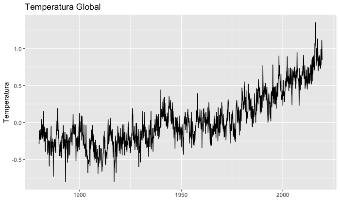

```r
autoplot(temp) +
  ggtitle("Temperatura Global") +
  xlab("") +
  ylab("Temperatura")
```

O gráfico acima apresenta o índice de temperatura global desde janeiro de 1880 até junho de 2019. Vamos realizar a separação em dados de treinamento e de teste. Os dados de treinamento compreenderão o período de janeiro de 2000 até dezembro de 2014, ao passo que os dados de teste compreendem o período de janeiro de 2015 até junho de 2019.

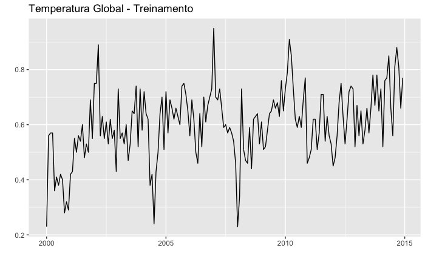

```r
temp_treinamento <- window(temp, start=c(2000,1), end=c(2014,12))
temp_teste <- window(temp, start =c(2015,1), end=c(2019,6))
autoplot(temp_treinamento) + ggtitle('Temperatura Global - Treinamento') + xlab('') + ylab('')
```

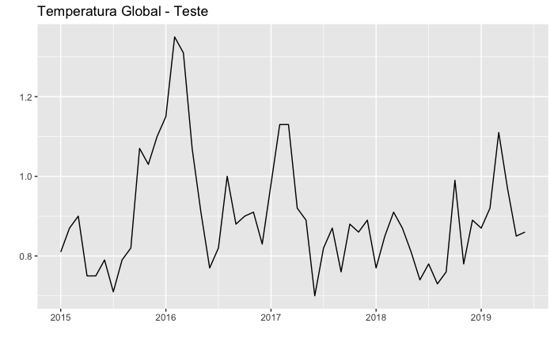

```r
autoplot(temp_teste) + ggtitle('Temperatura Global - Teste') + xlab('') + ylab('')
```

O próximo passo será realizar a decomposição da série temporal da temperatura global. Faremos a decomposição aditiva.

Decomposição Aditiva

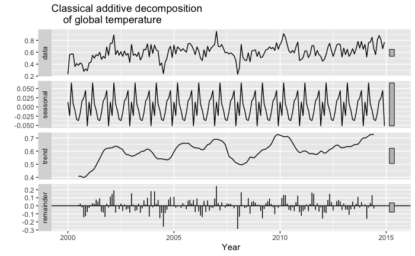

```r
temp_treinamento %>% decompose(type="additive") %>%
  autoplot() + xlab("Year") +
  ggtitle("Classical additive decomposition
    of global temperature")
```

Pela decomposição da série é possível perceber um comportamento sazonal e uma tendência estocástica, pois muda de comportamento ao longo do tempo.

O procedimento a seguir será o de tentar modelar a série de temperatura com o Holt-Winters.

#### Holt-Winters

O algoritmo de Holt-Winters serve para modelar séries com tendência e sazonalidade. A série de temperatura global possui sazonalidade, mas a tendência não é determinística.

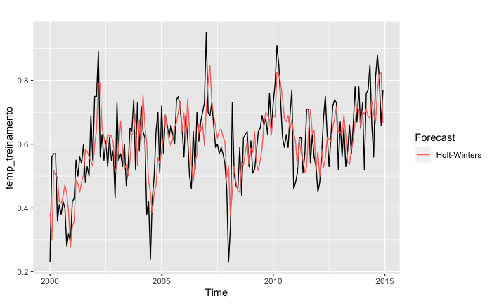

```r
temp_hw <- hw(temp_treinamento, damped = TRUE, seasnal = "additive", h =54)
autoplot(temp_treinamento) +
  autolayer(temp_hw$fitted, series = 'Holt-Winters')+
  guides(colour = guide_legend(title ="Forecast"))
```

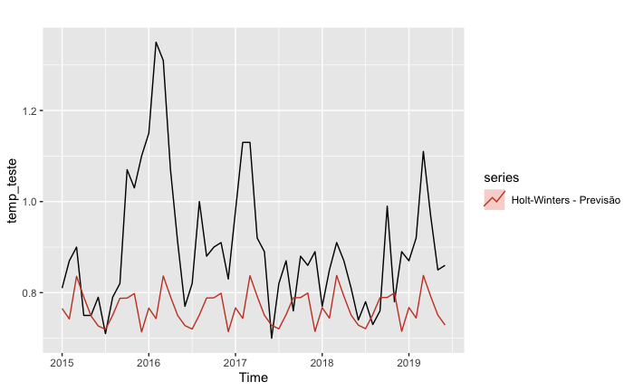

```r
temp_hw_forecast <- forecast::forecast(temp_hw, h = 54)

autoplot(temp_teste) +
  autolayer(temp_hw_forecast, PI = FALSE, series = 'Holt-Winters - Previsão')
```

O gráfico ACF e PACF para a série de temperatura global.

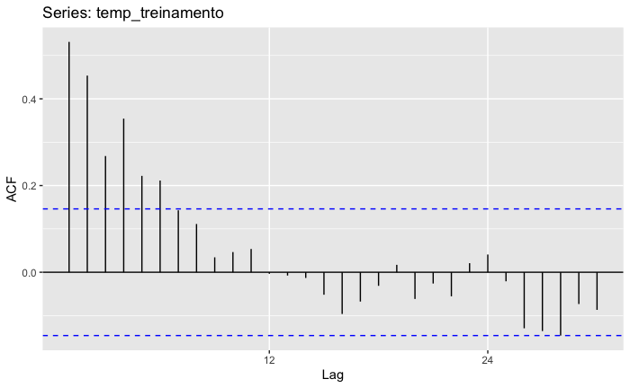

```r
ggAcf(temp_treinamento, lag = 30)
```

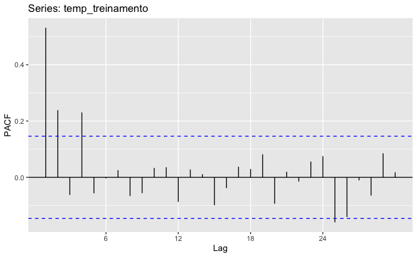

```r
ggPacf(temp_treinamento, lag  = 30)
```

#### AR

```r
#AR(2)

#AR(4)
```

#### ARMA

#### ARIMA

```r
arima <- auto.arima(window(serie2, start = c(2000,1),end = c(2018,12)))
arima
autoplot(forecast(arima, h = 6))
autoplot(arima$residuals)
ggAcf(arima$residuals)
ggPacf(arima$residuals)
```

[output not shown]

#### GARCH

#### Filtro de Kalman

### 3ª Série Temporal: Índice Ibovespa

```r
bvsp <- BVSP$BVSP.Close
autoplot(bvsp) + ggtitle('Índice Ibovespa de fechamento')
```

[output not shown]

```r
ggAcf(bvsp,30)
ggPacf(bvsp,30)
```

[output not shown]

#### Holt-Winters

#### AR

#### ARMA

#### ARIMA

#### GARCH

#### Filtro de Kalman